# Linear Regression Models: Generalized Linear Models

## Generalized Linear Models

- General Linear Model (GLM):
  - Continuous response
  - Allows for both continuous and categorical predictors
- Generalized Linear Model (GLM):
  - Allows for responses from non-normal distributions
  - Can have both types of predictors
- Logistic Reression, Poisson Regression, Negative Binomial Regression, Multiple Linear Regression all in the GLM framework

## Generalized Linear Models

- The `logit` function \(\left(log\left(\frac{p}{1-p}\right)\right)\) is called the *link* function
- **links** the mean (recall p = average number of successes at a given x) to the linear form of the model

## Generalized Linear Models

- The `logit` function \(\left(log\left(\frac{p}{1-p}\right)\right)\) is called the *link* function
- **links** the mean (recall p = average number of successes at a given x) to the linear form of the model
- Generally, we can look at a *link* function \(g\) where

\[g(\mu) = \beta_0 + \beta_1x_1+\beta_2x_2+...+\beta_px_p\]

where \(\mu\) is the mean for the set of \(x\) values used

## Generalized Linear Models

- The `logit` function \(\left(log\left(\frac{p}{1-p}\right)\right)\) is called the *link* function
- **links** the mean (recall p = average number of successes at a given x) to the linear form of the model
- Generally, we can look at a *link* function \(g\) where

\[g(\mu) = \beta_0 + \beta_1x_1+\beta_2x_2+...+\beta_px_p\]

where \(\mu\) is the mean for the set of \(x\) values used

- For standard linear regression \(g(\mu) = \mu\) (identity link)
  - Recall value predicted is *mean* response at a given x

## Generalized Linear Models

- For responses coming from an *exponential family* (optional reading [here](https://en.wikipedia.org/wiki/Exponential_family)), there are **natural** links that can be used

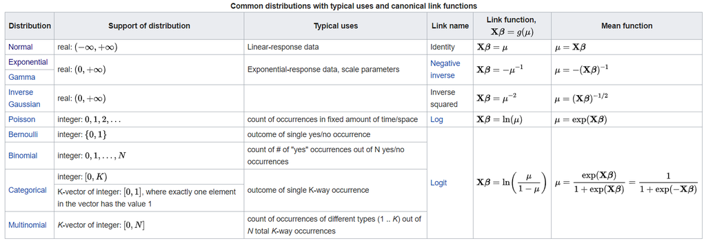

Courtesy of wikipedia

## Generalized Linear Models

- Lots of theory and connections with GLMs… focus on applications!
- Framework we are working in extends very easily!

## Generalized Linear Models

- Lots of theory and connections with GLMs… focus on applications!
- Framework we are working in extends very easily!
- Consider a data where the response could come from a Poisson distribution

```r
shipData <- read_table("../datasets/ships.dat") %>% select(-X1)
shipData
```

```
## # A tibble: 34 x 5
##   type  construction operation months damage
##   <chr> <chr>        <chr>      <int>  <int>
## 1 A     1960-64      1960-74      127      0
## 2 A     1960-64      1975-79       63      0
## 3 A     1965-69      1960-74     1095      3
## 4 A     1965-69      1975-79     1095      4
## 5 A     1970-74      1960-74     1512      6
## # ... with 29 more rows
```

## Poisson Distribution

Poisson distribution is useful for modeling counts

- Mean rate of occurrence of the distribution is usually denoted by \(\lambda\)
- Variance is also equal to \(\lambda\) (higher mean, more variable)
- Inference usually centered on \(\lambda\)

## Poisson Distribution

Poisson distribution is useful for modeling counts

- Mean rate of occurrence of the distribution is usually denoted by \(\lambda\)
- Variance is also equal to \(\lambda\) (higher mean, more variable)
- Inference usually centered on \(\lambda\)

Example applications

- # of car accidents in a week
- # of 911 calls in an hour
- # of deaths by horse-kick in a year (classic example :)

## Poisson Regression

```
## # A tibble: 34 x 5
##   type  construction operation months damage
##   <chr> <chr>        <chr>      <int>  <int>
## 1 A     1960-64      1960-74      127      0
## 2 A     1960-64      1975-79       63      0
## 3 A     1965-69      1960-74     1095      3
## 4 A     1965-69      1975-79     1095      4
## 5 A     1970-74      1960-74     1512      6
## # ... with 29 more rows
```

About the data:

- *type* - ship type, coded 1-5 for A, B, C, D and E

## Poisson Regression

```
## # A tibble: 34 x 5
##   type  construction operation months damage
##   <chr> <chr>        <chr>      <int>  <int>
## 1 A     1960-64      1960-74      127      0
## 2 A     1960-64      1975-79       63      0
## 3 A     1965-69      1960-74     1095      3
## 4 A     1965-69      1975-79     1095      4
## 5 A     1970-74      1960-74     1512      6
## # ... with 29 more rows
```

About the data:  
- *construction* - year of construction (1=1960-64, 2=1965-70, 3=1970-74, 4=1975-79)

## Poisson Regression

```
## # A tibble: 34 x 5
##   type  construction operation months damage
##   <chr> <chr>        <chr>      <int>  <int>
## 1 A     1960-64      1960-74      127      0
## 2 A     1960-64      1975-79       63      0
## 3 A     1965-69      1960-74     1095      3
## 4 A     1965-69      1975-79     1095      4
## 5 A     1970-74      1960-74     1512      6
## # ... with 29 more rows
```

About the data:  
- *operation* - period of operation (1=1960-74, 2=1975-79)

## Poisson Regression

```
## # A tibble: 34 x 5
##   type  construction operation months damage
##   <chr> <chr>        <chr>      <int>  <int>
## 1 A     1960-64      1960-74      127      0
## 2 A     1960-64      1975-79       63      0
## 3 A     1965-69      1960-74     1095      3
## 4 A     1965-69      1975-79     1095      4
## 5 A     1970-74      1960-74     1512      6
## # ... with 29 more rows
```

About the data:  
- *months* - **aggregated** months of service, ranging from 63 to 20,370

## Poisson Regression

```
## # A tibble: 34 x 5
##   type  construction operation months damage
##   <chr> <chr>        <chr>      <int>  <int>
## 1 A     1960-64      1960-74      127      0
## 2 A     1960-64      1975-79       63      0
## 3 A     1965-69      1960-74     1095      3
## 4 A     1965-69      1975-79     1095      4
## 5 A     1970-74      1960-74     1512      6
## # ... with 29 more rows
```

About the data:  
- *damage* - damage incidents caused by waves to the forward section, ranging from 0 to 53

## Poisson Regression

```
## # A tibble: 34 x 5
##   type  construction operation months damage
##   <chr> <chr>        <chr>      <int>  <int>
## 1 A     1960-64      1960-74      127      0
## 2 A     1960-64      1975-79       63      0
## 3 A     1965-69      1960-74     1095      3
## 4 A     1965-69      1975-79     1095      4
## 5 A     1970-74      1960-74     1512      6
## # ... with 29 more rows
```

About the data:  
Define \(Y_i\) as the damage for the \(i^{th}\) ship, then

\[Y_i\sim Poi(\lambda_i)\]

We'd like to model the \(\lambda_i\)

## Poisson Regression

We'd like to model the \(\lambda_i\)

- Issues: each ship has a different # of aggregate months, need to standardize
- Look at modeling \(\lambda_i/exposure_i\)

## Poisson Regression

We'd like to model the \(\lambda_i\)

- Issues: each ship has a different # of aggregate months, need to standardize
- Look at modeling \(\lambda_i/exposure_i\)
- For Poisson, use \(log\) link (natural)

\[ln(\lambda_i/exposure_i) = \beta_0 + \beta_1x_1 +... +\beta_px_p\]

- Can now rewrite to model \(\lambda_i\) (called a log-linear model)

\[ln(\lambda_i) = ln(exposure_i) + \beta_0 + \beta_1x_1 +... +\beta_px_p\]

- \(ln(exposure_i)\) called an *offset*

## Poisson Regression

- Fit using `glm()`
- Reference is first category of `type` variable

```r
poiFit <- glm(damage ~ offset(log(months)) + type, data = shipData, family = "poisson")
poiFit
```

```
##
## Call:  glm(formula = damage ~ offset(log(months)) + type, family = "poisson",
##     data = shipData)
##
## Coefficients:
## (Intercept)        typeB        typeC        typeD        typeE
##     -5.4202      -0.8837      -0.8260      -0.1459       0.3429
##
## Degrees of Freedom: 33 Total (i.e. Null);  29 Residual
## Null Deviance:       146.3
## Residual Deviance: 90.89     AIC: 198.8
```

```
##               Estimate Std. Error     z value      Pr(>|z|)
## (Intercept) -5.4202189  0.1543033 -35.1270332 2.606932e-270
## typeB       -0.8836950  0.1666196  -5.3036679  1.134987e-07
## typeC       -0.8260494  0.3273254  -2.5236337  1.161489e-02
## typeD       -0.1458779  0.2874595  -0.5074729  6.118230e-01
## typeE        0.3428989  0.2346477   1.4613355  1.439234e-01
```

```
## [1] "Deviance = 90.89 DF = 29"
```

## Poisson Regression

- Prediction the same, type = "response" exponentiates result

```r
predict(poiFit, newdata = data.frame(months = c(1000, 1000, 4000), type = c("A", "B", "B")),
                type = "response", se.fit = TRUE)
```

```
## $fit
##        1        2        3
## 4.426178 1.829132 7.316527
##
## $se.fit
##         1         2         3
## 0.6829740 0.1149965 0.4599861
##
## $residual.scale
## [1] 1
```

## Poisson Regression

Model fit:

- One thing to look at for a Poisson regression model fit is deviance
- Deviance is a measure of goodness-of-fit
- A bit beyond this course, but we hope that the residual deviance/df \(\approx\) 1

## Poisson Regression

Model fit:

- One thing to look at for a Poisson regression model fit is deviance
- Deviance is a measure of goodness-of-fit
- A bit beyond this course, but we hope that the residual deviance/df \(\approx\) 1
- Here much larger, overdispersion or other lack of fit present
- Overdispersion is where the observed variance is higher than the theoretical variance
- Theoretically for Poisson, var = mean
- Solution: Add more explanatory variables, model overdispersion parameter, or switch to negative binomial regression

## Recap!

- Should always do Exploratory Data Analysis (EDA)
  - Plot data, summarize it across variables
- Linear regression models
  - Use `lm()`
- Generalized Linear Regresion models
  - Use `glm()` with appropriate `link`
- Predict using `predict()`